# Is James Harden the System?

Question: Is James Harden the System?

The 3 questions I wanted to further explore are:

- How is the Clippers offensive and Defensive rating affected by Harden being on the court?
- Does Harden’s usage rate inflate his stats making him look better than he actually is?
- How does James Harden compare to other players around the league on his impact on his team?

Context: At the start of 2024-2025 season, James Harden was asked what the clippers system was going to be for the upcoming season and he said “I am the system”. I wanted to test his claim as to if he was the system throughout the 24-25 season.

Data cleaning: To clean the data I had to create 2 data sets one with team data and one with player data. For the team data, I first made a Acronym column that I could use to add acronyms to my graph. Then I imported the table that I wanted to use and left joined those data sets. For my Player data I first made sure there was only one of every player. Then I set a minimum of 41 games played as a cut off for players. 41 games is half of the NBA season so I felt like it was a fair line to draw for a players games played to be meaningful.

Sources: All my data is from [Basketball reference](https://www.basketball-reference.com/). I went around I collected my own data around the website whether it was on James Harden, Every Player, and Every team

[figure not shown]

James Harden (aka: The Beard)

[interactive chart not shown]

Offensive Rating and Defensive Rating are Stats that measure the points scored and allowed per 100 possesions. This method allows us to adjust for pace and allows a fair comparison.

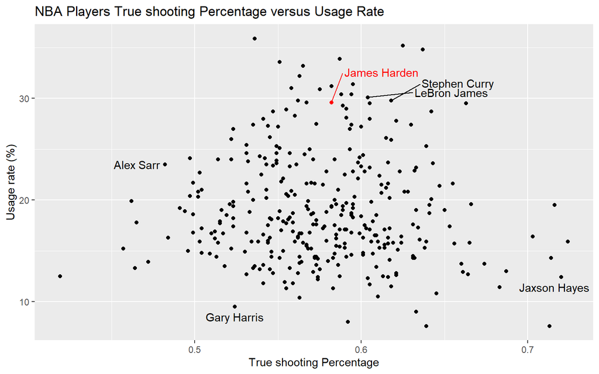

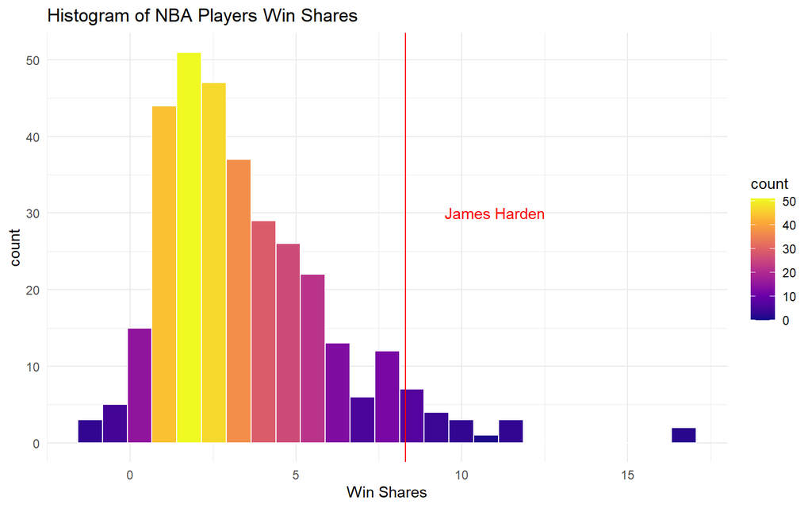

The Scatter plot uses 2 variables, True shooting and Usage percentage. True shooting percentage is calculated by combining 2 pointers, 3 pointers, and free throws. Showing how many shots they make in all their shot attempts. Usage rate estimates the percent of possessions a player ends the play with a shot attempt. This shows their offensive load and importance for the team. The 2 combined allow for us to quickly see how a player is effecting the game for his team.

The Histogram looks at a players win share. Win share is a statistics that explain how an individual is credited for team success. It is related to a teams win total and players can have positive or negative win shares based on their effect on their team.

Resources I used:  
- ChatGPT to help me clear through my errors by putting the error codes into chat and learning how to fix them  
- RGallery to look at different ideas for my graph  
- Stack Overflow to think of ideas on how to repel points away from each other  
- Cheat sheets for ggplot, dplyr, and repel to understand how to use the packages and edit my code

Formal Citations:

OpenAI. (2025). ChatGPT (GPT-5, Thinking; Nov 10, 2025 version) [Large language model]. OpenAI. https://chat.openai.com/

Holtz, Y. (n.d.). Help and inspiration for R charts. Retrieved from https://r-graph-gallery.com/

Cheatsheets. (2023b). Retrieved from https://posit.co/resources/cheatsheets/